# HW3 Instructions

R script due Thursday 10/1/20 by 12:01 PM to Canvas

## Instructions

For your assignment, you will be writing code to recreate these plots (they aren’t necessarily the most beautiful, but they will teach different plotting skills!). Please use the provided `hw3.R` R script template in the class RStudio Cloud Workspace. You will find the dataset `sparrows` has been pre-loaded for you in the associated cloud project.

For each question, you should:

- Write code to recreate the plot. *Save* the plot to a variable and *print* that variable with `print()`.
- Ensure your code contains comments!!

For ensured success, please make sure to do the following:

- **Ask me for help AT LEAST 24 hours before the deadline. I cannot guarantee time to help you if only short notice is given. Given my schedule, I can probably (unfortunately) guarantee that I won’t have time to help.**
- Write all code yourself and include COMMENTS for each plot you create.
- Please *comment out* (add `#` in front of) code that causes errors or bugs. This will ensure that your code runs without errors, while also showing me your code attempt if you only got part-way through recreating the plot.
- **NEVER EVER OVERWRITE THE VARIABLE `sparrows` BEYOND REPAIR.** Be especially careful in plots 3-4. It is HIGHLY RECOMMEND you make a *copy* of the variable if you are ever going to change it, as you may need to do to make plots 3-4. For example, `sparrows_plot3 <- sparrows`. You can then work with the `sparrows_plot3` version to create plot 3 while preserving the accuracy of `sparrows`.
  - If something goes *very wrong* with the `sparrows` variable, you can re-load it with this code (don’t worry about what the code means, just copy/paste it into console to restore the data). Hopefully this won’t happen to you! *If you need to do this, DO NOT place it into your submitted R script. Just run it in the Console directly.*

    ```
    readr::read_csv("sparrows.csv") dplyr::`%>%`
      dplyr::mutate(Age = as.factor(Age),
                    Survival = as.factor(Survival),
                    Sex = as.factor(Sex)) -> sparrows
    ```

- I have included some colors and fills. You do NOT HAVE TO EXACTLY MATCH my color/fill choices, but you should include a color and/or fill of your choice so that the conceptual style matches. In other words, if I use a color, you should also use a color, but the exact color can be different. *Aside from specific color/fills, ALL aspects of the plot should exactly match mine.* The one other exception is *sizes* - try to approximate my sizes, but you may not be able to get the exact size right. The key is - if you notice my plot has a different size than default, try to match!
- All plots use one of either `theme_gray()` (the default theme), `theme_classic()`, `theme_bw()`, or `theme_minimal()`. You should match the theme in the plots provided.

### Plot 1

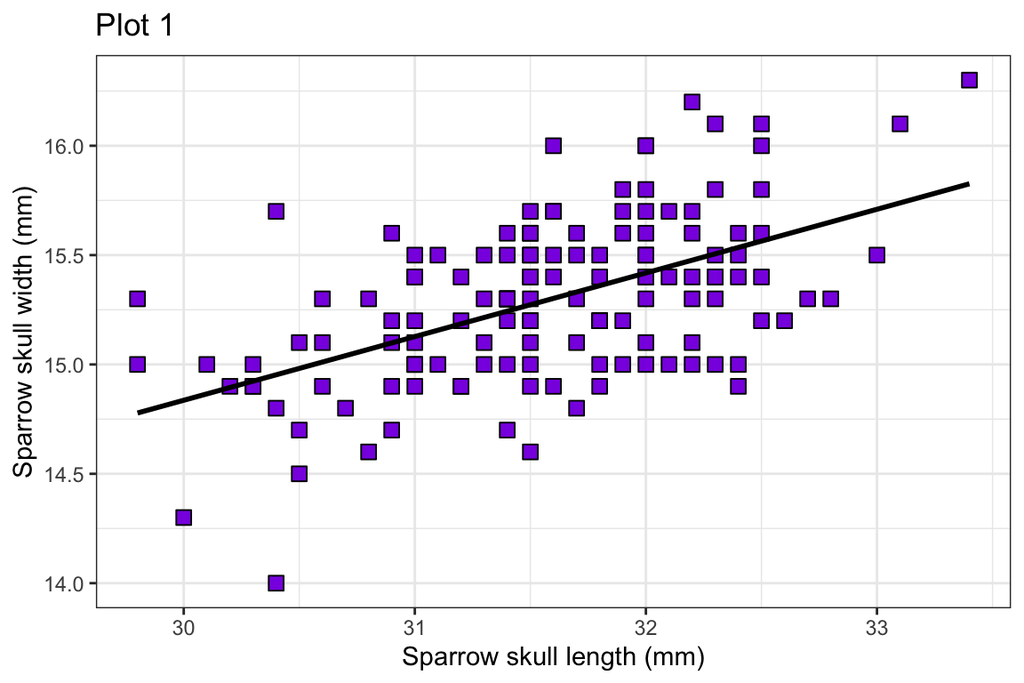

### Plot 2

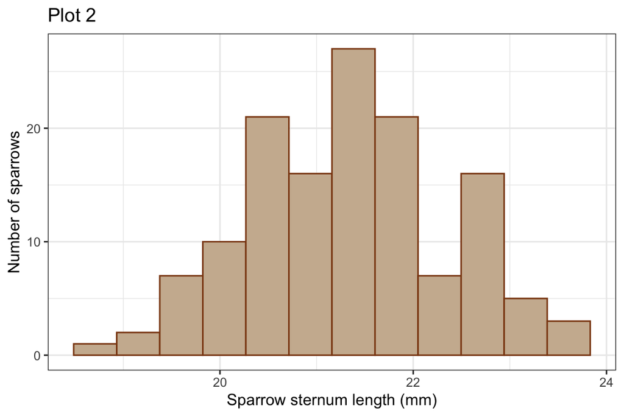

### Plot 3

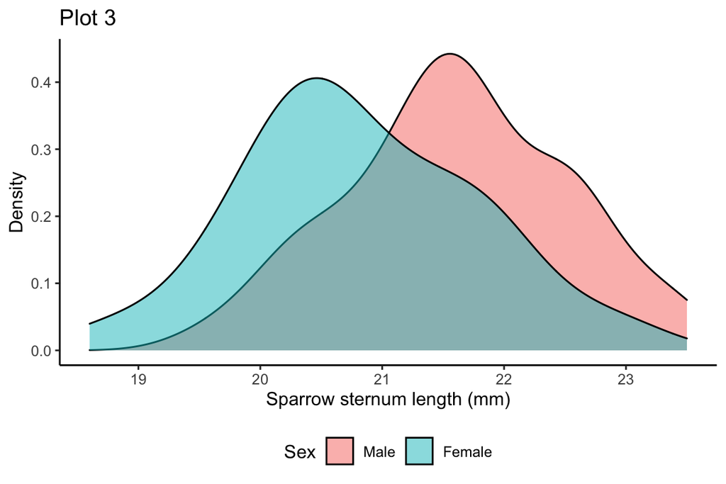

Hints:

- Make sure your *order of variables* agrees with this plot!! Think: *factors*.
  - Bear in mind that if you change any data here, it will remain changed throughout the rest of your script. Maybe later you’ll need to have code to change things back??
- This plot places the legend at the bottom of the plot. This is actually a modification to the plot’s theme. Because `ggplot` plots are just added components *on top of one another*, you will need to change the legend position AFTER you set a baseline theme (think about why this MUST BE THE CASE, and experiment with it!). The legend can be repositioned with the following code: `theme(legend.position = "bottom")`. To learn more (but not to submit!), you can see what happens if you use “top”, “left”, or “right” instead of “bottom”.

### Plot 4

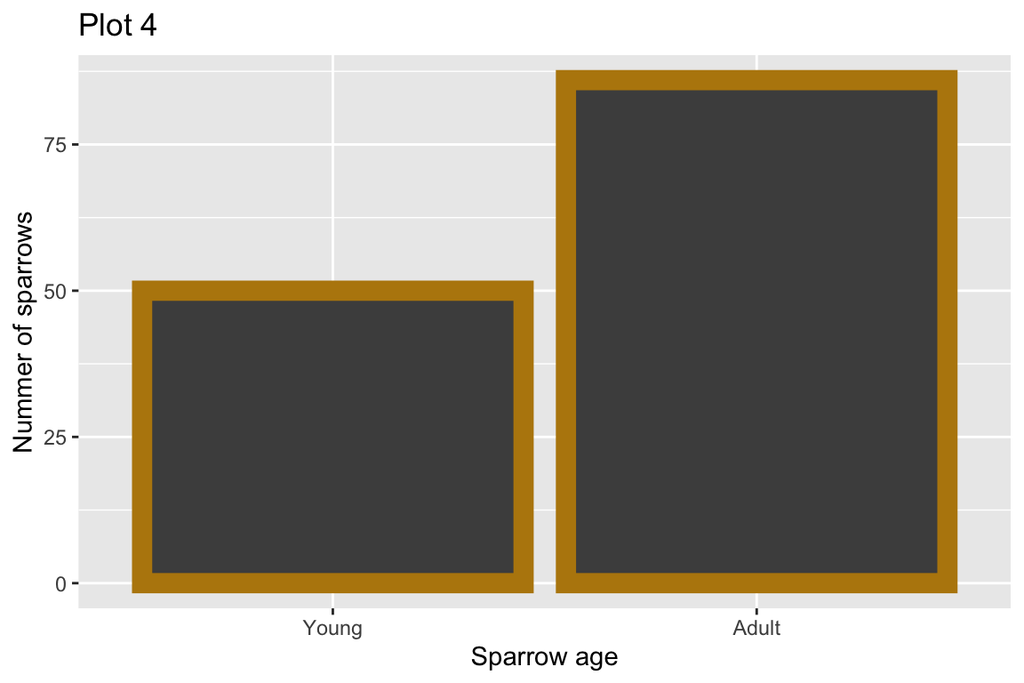

### Plot 5

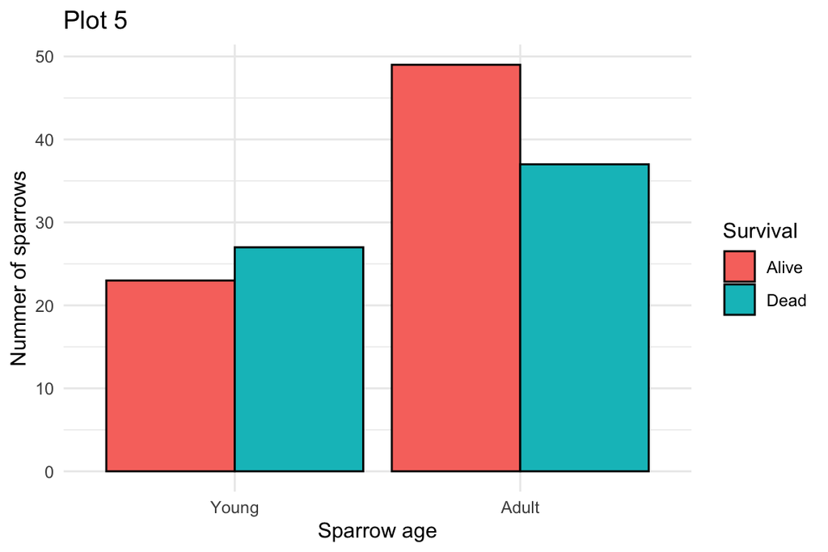

### Plot 6

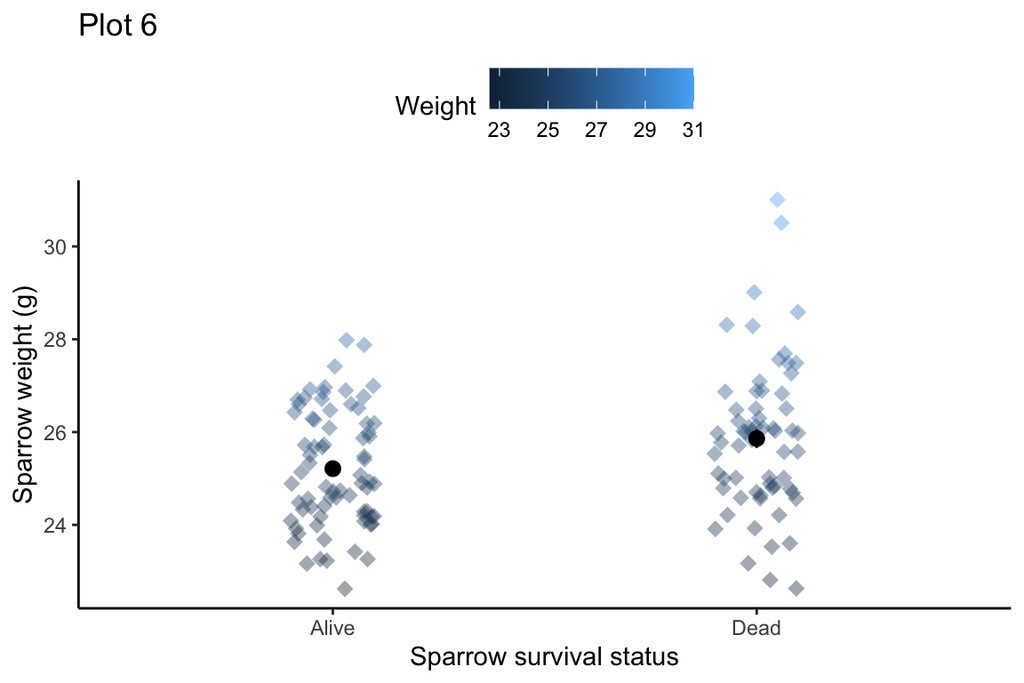

Hints:

- See the *black point with small lines* in each distribution? This represents the *mean and standard error (SE)* of each distribution. In this case, the standard errors are very small, so the lines are a bit tricky to see, but they are there! These points are conveniently, amazingly, and automatically added with the plot component, `stat_summary()`. This is a special `ggplot2` function which can easily add a *summary statistic* onto a plot. No arguments are necessary - by default, it plots mean and SE.
  - It will reveal a warning message: “No summary function supplied, defaulting to `mean_se()`,” which means you used it CORRECTLY!!

### Plot 7

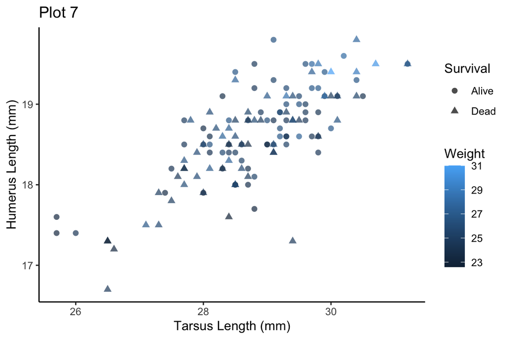

## BONUS PLOT

*Including this plot is optional, but HIGHLY encouraged. Partial credit is always given for attempts, but as always, there should still not be any bugs.*

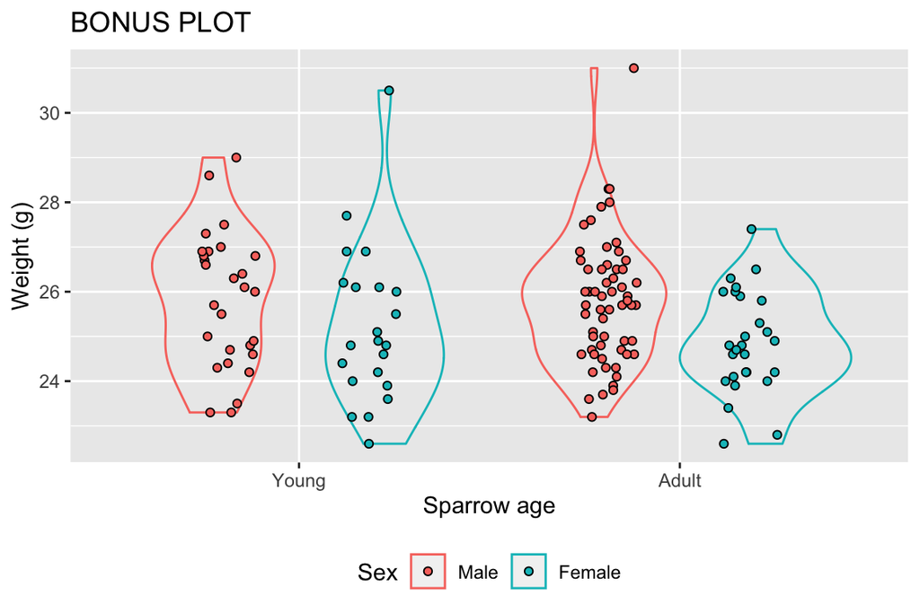

Hints:

- There are *two* geoms used here, one on top of the other. Since `ggplot2` adds plot layers in order on top of one another, think carefully about which geom comes first in the code.
- The geoms use different but similar mappings. *Think carefully about where these aesthestics need to be placed in the code?* For SHARED mappings, place in the `aes()` inside the main `ggplot()` call. For mapping UNIQUE to a geom, place the `aes()` inside the relevant geom itself.
- Having no fill is like having total transparency.